# Hypothesis Testing in R

Martin Treppner, Clemens Kreutz, Eva Brombacher, Eva Kohnert

Institute of Medical Biometry and Statistics, Faculty of Medicine and Medical Center - University of Freiburg

January 08, 2021

# Introduction

Welcome to *Hypothesis Testing in R*!

Hypothesis testing plays a prominent role in biology, mainly because many decisions in the research process are based on it. Another aspect that is used especially in biology are methods of multiple testing where thousands of hypotheses are examined to filter out the most promising ones (Holmes and Huber (2018)).

# Coin tossing example

To simulate a coin flip experiment in R, we use the `sample` function. But first we have to think about some of the parameters.

Since we wanted to generate random numbers, we first need to set a random seed using the `set.seed` function.

Since the random numbers generated in R are not really random, but pseudorandom numbers, we can choose any seed for which then always the same random numbers are generated. An andom seed is often used to ensure the reproducibility of the results.

Here we “flip” a biased coin which comes up head with probability 0.6 and tails with probability 0.4.

```r
set.seed(123)
#set.seed(59)
numFlips = 100
probHead = 0.6
coinFlips = sample(c("H", "T"), size = numFlips,
  replace = TRUE, prob = c(probHead, 1 - probHead))
head(coinFlips)
```

```
## [1] "H" "T" "H" "T" "T" "H"
```

```r
table(coinFlips)
```

```
## coinFlips
##  H  T
## 60 40
```

If the coin were fair, we would expect heads to come up with probability of 0.5.

Suppose someone were to show you the data without giving you any information about whether the coin is fair or not. The assumption is that the coin is fair, that is, it has a 50% chance of landing on heads. Would you reject the hypothesis that the coin is fair based on the data you observed?

In order to be able to make a statement about this, we can simulate the corresponding sampling distribution, i.e. a binomial distribution.

The probability of observing heads, assuming that the coin is fair, is 50%. We specify this in the argument `prob`. The number of coin flips is defined in the `size` argument. And `k` shows all possible outcomes of seeing heads for the 100 coin flips.

```r
library("dplyr")
k = 0:numFlips
numHeads = sum(coinFlips == "H")
binomDensity = tibble(k = k,
     p = dbinom(k, size = numFlips, prob = 0.5))
```

If we plot the resulting binomial distribution and look at where our observations lie using a vertical line, we get an idea of how likely this result is under the null hypothesis of a fair coin.

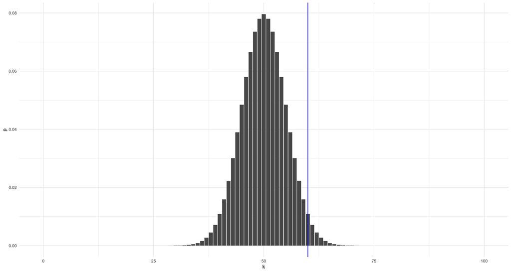

```r
library("ggplot2")
ggplot(binomDensity) +
  geom_bar(aes(x = k, y = p), stat = "identity") +
  geom_vline(xintercept = numHeads, col = "blue") +
  theme_minimal()
```

Next, we divide the set of all possible outcomes k into two subsets. The **rejection region** and the region of no rejection (Holmes and Huber (2018)).

Simply put, we fill the rejection region with as many k as possible so that its total probability (under the null hypothesis) is below our threshold $\alpha$ (Holmes and Huber (2018)).

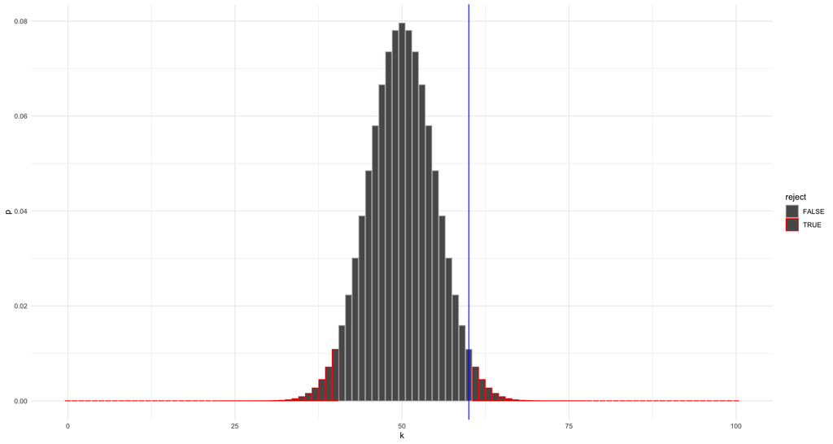

```r
library("dplyr")
alpha = 0.05
binomDensity = arrange(binomDensity, p) %>%
        mutate(reject = (cumsum(p) <= alpha))

ggplot(binomDensity) +
  geom_bar(aes(x = k, y = p, col = reject), stat = "identity") +
  scale_colour_manual(
    values = c(`TRUE` = "red", `FALSE` = "darkgrey")) +
  geom_vline(xintercept = numHeads, col = "blue") +
  theme(legend.position = "none") +
  theme_minimal()
```

Since this is a common method, there is the `binom.test` function for this purpose.

```r
binom.test(x = numHeads, n = numFlips, p = 0.5)
```

```
##
##  Exact binomial test
##
## data:  numHeads and numFlips
## number of successes = 60, number of trials = 100, p-value = 0.05689
## alternative hypothesis: true probability of success is not equal to 0.5
## 95 percent confidence interval:
##  0.4972092 0.6967052
## sample estimates:
## probability of success
##                    0.6
```

# The five steps of hypothesis testing

From Holmes and Huber (2018):

1. Decide on the effect that you are interested in, design a suitable experiment or study, pick a data summary function and test statistic.
2. Set up a null hypothesis, which is a simple, computationally tractable model of reality that lets you compute the null distribution, i.e., the possible outcomes of the test statistic and their probabilities under the assumption that the null hypothesis is true.
3. Decide on the rejection region, i.e., a subset of possible outcomes whose total probability is small.
4. Do the experiment and collect the data; compute the test statistic.
5. Make a decision: reject the null hypothesis if the test statistic is in the rejection region.

# Types of error

From Holmes and Huber (2018):

Types of error in a statistical test.

| Test vs reality | Null hypothesis is true | $...$ is false |
| --- | --- | --- |
| **Reject null hypothesis** | Type I error (false positive) | True positive |
| **Do not reject** | True negative | Type II error (false negative) |

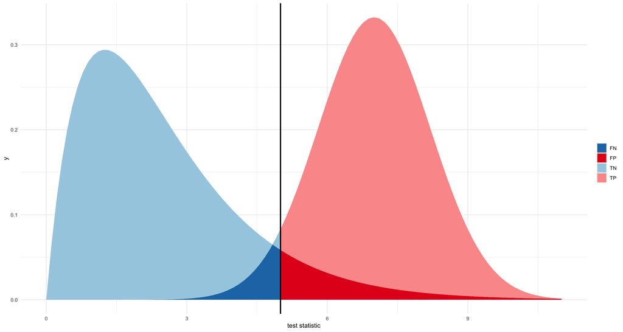

```r
list(
  tibble(
    x = px[c(i1, rev(i1))],
    y = c(f2[i1], f1[rev(i1)]),
    ` ` = "TN"),
  tibble(
    x = px[c(i1, rev(i1))],
    y = c(rep(0, length(i1)), f2[rev(i1)]),
    ` ` = "FN"),
  tibble(
    x = px[c(i2, rev(i2))],
    y = c(f1[i2], f2[rev(i2)]),
    ` ` = "TP"),
  tibble(
    x = px[c(i2, rev(i2))],
    y = c(rep(0, length(i2)), f1[rev(i2)]),
    ` ` = "FP")) %>% do.call(rbind, .) %>%
ggplot(aes(x = x, y = y, fill = ` `)) + geom_polygon() +
  scale_fill_manual(values = brewer.pal(12, "Paired")[c(2, 1, 6, 5)] %>%
     `names<-`(c("FN", "TN", "FP", "TP"))) +
  geom_vline(xintercept = px[i2[1]], col = "black", size = 1) +
  xlab("test statistic") +
  theme(legend.position="none") +
  theme_minimal()
```

# The t-test

First, we again load a sample data set from R. These are the data from a plant growth experiment in which the yields (as measured by dried weight of plants) were compared between a control and two treatment groups.

```r
data("PlantGrowth")
head(PlantGrowth)
```

```
##   weight group
## 1   4.17  ctrl
## 2   5.58  ctrl
## 3   5.18  ctrl
## 4   6.11  ctrl
## 5   4.50  ctrl
## 6   4.61  ctrl
```

By visual inspection, we find it difficult to decide if there is a difference between the groups.

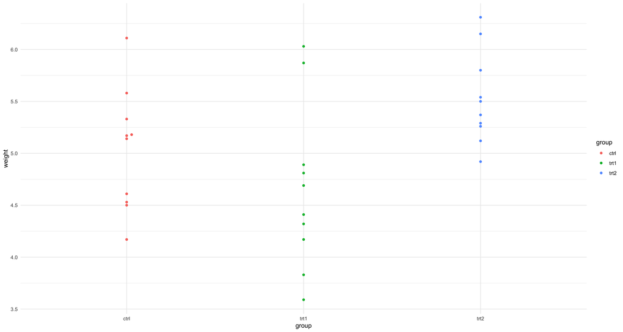

```r
library("ggbeeswarm")
ggplot(PlantGrowth, aes(y = weight, x = group, col = group)) +
  geom_beeswarm() + theme(legend.position = "none") + theme_minimal()
```

However, when we compare the control group with the second treatment group in a t-test, we see that the yield is significantly different between the two groups.

```r
tt = with(PlantGrowth,
          t.test(weight[group =="ctrl"],
                 weight[group =="trt2"],
                 var.equal = TRUE)
          )
tt
```

```
##
##  Two Sample t-test
##
## data:  weight[group == "ctrl"] and weight[group == "trt2"]
## t = -2.134, df = 18, p-value = 0.04685
## alternative hypothesis: true difference in means is not equal to 0
## 95 percent confidence interval:
##  -0.980338117 -0.007661883
## sample estimates:
## mean of x mean of y
##     5.032     5.526
```

**Exercise:**

To better understand the `with` function, perform a t-test for both the comparison of the control group with treatment 1 and treatment 2 and store both results in a list.

```r
t_list = with(PlantGrowth,
          list(t.test(weight[group =="ctrl"],
                 weight[group =="trt2"],
                 var.equal = TRUE),
          t.test(weight[group =="ctrl"],
                 weight[group =="trt1"],
                 var.equal = TRUE)))
t_list
```

```
## [[1]]
##
##  Two Sample t-test
##
## data:  weight[group == "ctrl"] and weight[group == "trt2"]
## t = -2.134, df = 18, p-value = 0.04685
## alternative hypothesis: true difference in means is not equal to 0
## 95 percent confidence interval:
##  -0.980338117 -0.007661883
## sample estimates:
## mean of x mean of y
##     5.032     5.526
##
##
## [[2]]
##
##  Two Sample t-test
##
## data:  weight[group == "ctrl"] and weight[group == "trt1"]
## t = 1.1913, df = 18, p-value = 0.249
## alternative hypothesis: true difference in means is not equal to 0
## 95 percent confidence interval:
##  -0.2833003  1.0253003
## sample estimates:
## mean of x mean of y
##     5.032     4.661
```

When using a t-test, we make the assumption that the test statistic, under the null hypothesis, follows a t-distribution. Furthermore, we assume that the observations are independent and come from a normal distribution with the same standard deviation.

In our case, at least one of the assumptions seems to be violated. Since we consider the weight of the plants and this must be positive, the assumption of normality is violated. To find out if this makes a difference to the result of our t-test, we can perform a permutation test.

For this we use again the `with` function and extract with the `filter` function from the `dplyr` packet all weights of the control group and the treatment 2 group.

We then apply the t-test 10000 times, randomly swapping the group membership of the weights each time. Last but not least, we extract the test statistics using the `$` symbol.

```r
abs_t_null = with(
  dplyr::filter(PlantGrowth, group %in% c("ctrl", "trt2")),
    replicate(10000,
      abs(t.test(weight ~ sample(group))$statistic)))
```

Next, we can look at the distribution of the 10000 test statistics under the null hypothesis and assess into which region our test statistic that we calculated from the data falls.

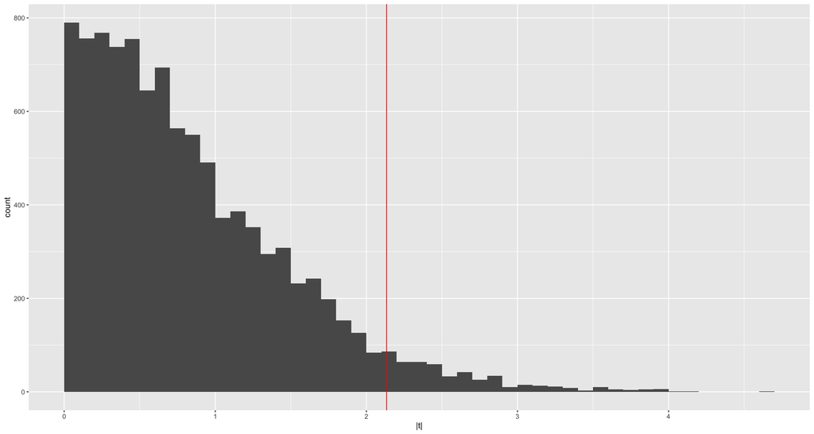

```r
ggplot(tibble(`|t|` = abs_t_null), aes(x = `|t|`)) +
  geom_histogram(binwidth = 0.1, boundary = 0) +
  geom_vline(xintercept = abs(tt$statistic), col = "red")
```

```r
mean(abs(tt$statistic) <= abs_t_null)
```

```
## [1] 0.0475
```

### The independence assumption

What happens when we duplicate the data?

```r
with(rbind(PlantGrowth, PlantGrowth),
       t.test(weight[group == "ctrl"],
              weight[group == "trt2"],
              var.equal = TRUE))
```

```
##
##  Two Sample t-test
##
## data:  weight[group == "ctrl"] and weight[group == "trt2"]
## t = -3.1007, df = 38, p-value = 0.003629
## alternative hypothesis: true difference in means is not equal to 0
## 95 percent confidence interval:
##  -0.8165284 -0.1714716
## sample estimates:
## mean of x mean of y
##     5.032     5.526
```

The means remain the same, but the p-value has become much smaller!

This shows us two things. First, we see that the quality of the t-test depends on the number of cases. Accordingly, as the number of cases increases, we also get more significant results. What is relevant, however, is whether the effect, i.e. the difference between the two groups, is also relevant. The distinction between significance and relevance is particularly important. This effect of an artificially increased number of cases is reflected, for example, in technical replicates. For example, if you are examining data from 8 plants but have taken two measurements from each plant, then if you continue to work with the assumption of having 16 observations, you will artificially decrease your p-value (Holmes and Huber (2018)).

# P-values

### Simulate data distributions of two populations

To demonstrate the variability of the p value introduced by different sample sizes we simulate two normally distributed data samples with different means. In the context of single cell RNA-seq this would correspond to differentially expressed genes with mean shift of 0.5.

```r
library(tidyverse)
library(magrittr)
library(ggpubr)
library(ggplot2)
library(reshape2)
```

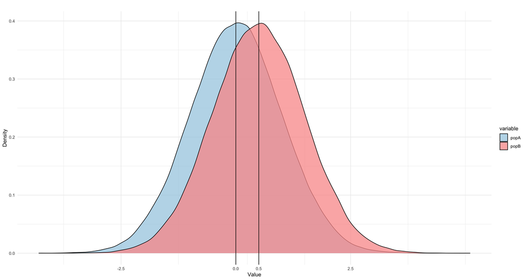

```r
n <- 100000
popA <- rnorm(n,mean = 0, sd = 1)
popB <- rnorm(n,mean = 0.5, sd = 1)

x <-  as.data.frame(cbind(popA,popB))
data <- melt(x)
ggplot(data,aes(x=value, fill=variable)) +
  geom_density(alpha=0.75) +
  geom_vline(xintercept=0.5) +
  geom_vline(xintercept=0) +
  ggtitle("") +
  scale_x_continuous(name ="Value",breaks=c(-2.5,0,0.5,2.5)) +
  scale_y_continuous(name ="Density") +
  theme(plot.title = element_text(hjust = 0.5,size=32),
        axis.text=element_text(size=22),
        legend.position="none",
        axis.title=element_text(size=32,face="bold")) +
  theme_minimal() +
  scale_fill_manual(values = brewer.pal(12, "Paired")[c(1, 5)] %>%
     `names<-`(c("popA", "popB")))
```

### Draw samples of ten values at random from each of the populations

We then draw samples of size ten (10 cells) randomly from each of the two populations.

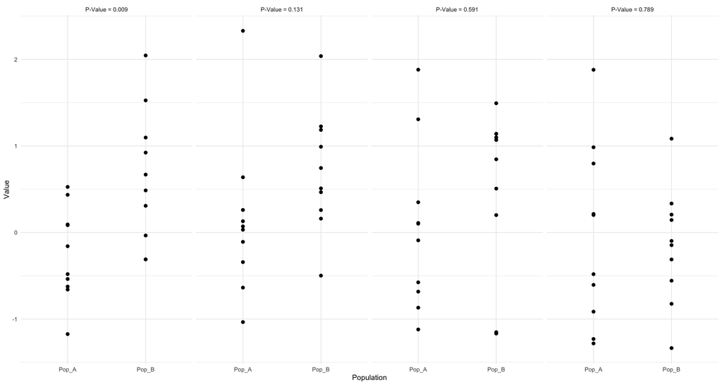

### A larger sample size estimates effect size more precisely.

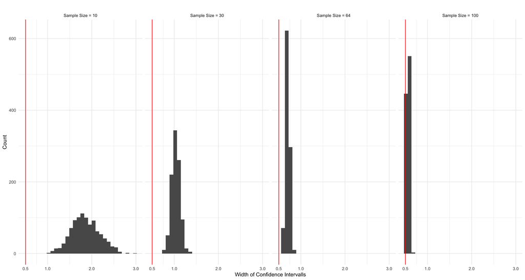

### Sample size affects the distribution of p values

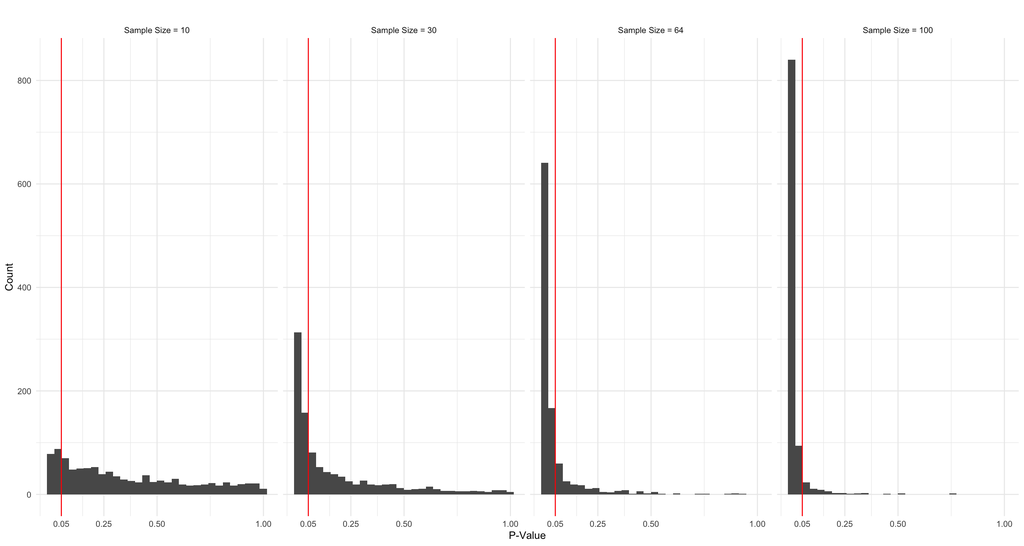

These figures are reproduced from: Halsey et al. (2015)

# Multiple testing

A prominent example of multiple testing is testing for differential expression of, say, 20,000 genes.

Applying the above table for the different types of errors in hypothesis testing to the multiple testing scenario, we get the following table:

Types of error in multiple testing. The letters designate the number of times each type of error occurs.

| Test vs reality | Null hypothesis is true | $...$ is false | Total |
| --- | --- | --- | --- |
| **Rejected** | $V$ | $S$ | $R$ |
| **Not rejected** | $U$ | $T$ | $m-R$ |
| **Total** | $m_0$ | $m-m_0$ | $m$ |

- $m$: total number of hypotheses
- $m_0$: number of null hypotheses
- $V$: number of false positives (a measure of type I error)
- $T$: number of false negatives (a measure of type II error)
- $S$, $U$: number of true positives and true negatives
- $R$: number of rejections

With the methods of multiple testing we want to make sure that the type I and type II errors are within the limits we have set before.

Holmes and Huber (2018)

## The family wise error rate

The family wise error rate (FWER) is the probability that $V > 0$, i.e., that we make one or more false positive errors (Holmes and Huber (2018)).

The formula for calculating the FWER can be calculated by taking the complement of making no false positive errors at all $P(V > 0)$.

$$P(V > 0) = 1 - P(no \quad rejecetion \quad of \quad any \quad of \quad m_0) = 1-(1-\alpha)^{m_0} \rightarrow 1 \quad as \quad m_0 \rightarrow \infty$$

**Exercise:**

Prove that the probability does indeed become very close to 1 when $m_0$ is large.

```r
m_0 <- c(5, 10, 25, 50, 100, 1000)
alpha <- 0.05
1 - (1 - alpha)^m_0
```

```
## [1] 0.2262191 0.4012631 0.7226104 0.9230550 0.9940795 1.0000000
```

### Bonferroni correction

How are we to choose the per-hypothesis $\alpha$ if we want FWER control?

Usually we do not know the true number of correct null hypothesis ($m_0$). However, we know the total number of hypotheses ($m$) we want to test which gives us an upper limit for $m_0$. Accordingly, we can simply divide our alpha level by the total number of hypotheses tested ($\alpha = \alpha_{FWER} / m$) to conservatively control the FWER.

Here, the red line indicates the alpha level ($\alpha = 0.05$). The alpha level that is given by the Bonferroni correction is $0.05 / m = 0.05 / 10000 = 0.000005 = 5e-06$. Hence, if we plot the alpha level against the probability of no false rejection we get the point where both lines intersect at $\alpha = 0.00000513 = 5.13e-06$.

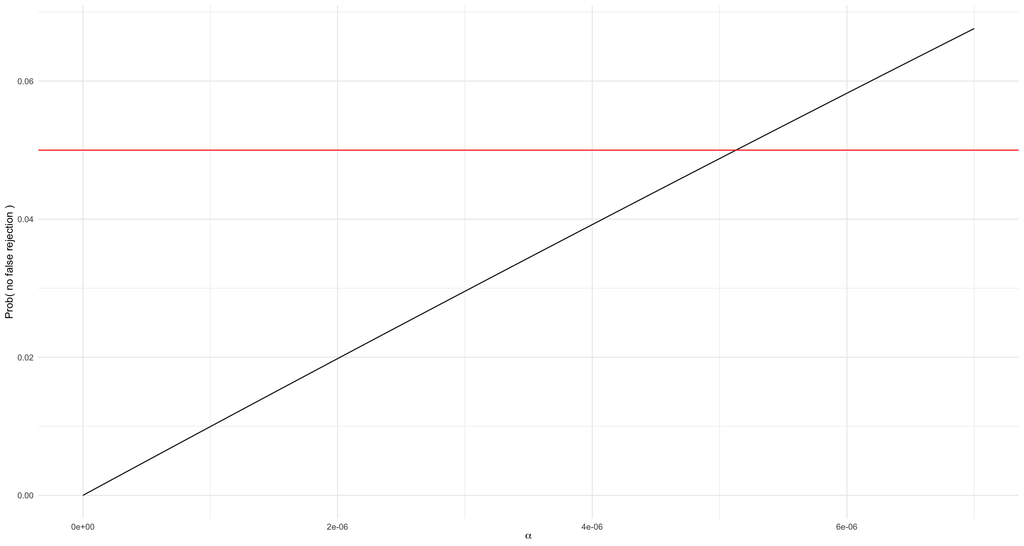

```r
m = 10000
ggplot(tibble(
  alpha = seq(0, 7e-6, length.out = 100),
  p     = 1 - (1 - alpha)^m),
  aes(x = alpha, y = p)) +  geom_line() +
  xlab(expression(alpha)) +
  ylab("Prob( no false rejection )") +
  geom_hline(yintercept = 0.05, col = "red") +
  theme_minimal()
```

## The false discovery rate

Again, to be somewhat application-oriented, we use an RNA-seq dataset called `airway` to illustrate the false discovery rate.

The dataset consists of gene expression data from four primary human airway smooth muscle cell lines with and without treatment with dexamethasone (Holmes and Huber (2018)). Based on this dataset, we will test whether the genes therein are differentially expressed.

```r
library("DESeq2")
library("airway")
data("airway")
```

```r
head(airway@assays$data$counts)
```

```
##      [,1] [,2] [,3] [,4] [,5] [,6] [,7] [,8]
## [1,]  679  448  873  408 1138 1047  770  572
## [2,]    0    0    0    0    0    0    0    0
## [3,]  467  515  621  365  587  799  417  508
## [4,]  260  211  263  164  245  331  233  229
## [5,]   60   55   40   35   78   63   76   60
## [6,]    0    0    2    0    1    0    0    0
```

You will get to know some details about the DESeq method in next weeks workshop.

```r
aw   = DESeqDataSet(se = airway, design = ~ cell + dex)
aw   = DESeq(aw)
awde = as.data.frame(results(aw)) %>% dplyr::filter(!is.na(pvalue))
```

```r
results(aw)
```

```
## log2 fold change (MLE): dex untrt vs trt
## Wald test p-value: dex untrt vs trt
## DataFrame with 64102 rows and 6 columns
##                  baseMean log2FoldChange     lfcSE      stat      pvalue
##                 <numeric>      <numeric> <numeric> <numeric>   <numeric>
## ENSG00000000003  708.6022      0.3812540  0.100654  3.787752 0.000152016
## ENSG00000000005    0.0000             NA        NA        NA          NA
## ENSG00000000419  520.2979     -0.2068126  0.112219 -1.842943 0.065337292
## ENSG00000000457  237.1630     -0.0379204  0.143445 -0.264356 0.791505742
## ENSG00000000460   57.9326      0.0881682  0.287142  0.307054 0.758801924
## ...                   ...            ...       ...       ...         ...
## LRG_94                  0             NA        NA        NA          NA
## LRG_96                  0             NA        NA        NA          NA
## LRG_97                  0             NA        NA        NA          NA
## LRG_98                  0             NA        NA        NA          NA
## LRG_99                  0             NA        NA        NA          NA
##                       padj
##                  <numeric>
## ENSG00000000003 0.00128363
## ENSG00000000005         NA
## ENSG00000000419 0.19654609
## ENSG00000000457 0.91145948
## ENSG00000000460 0.89503278
## ...                    ...
## LRG_94                  NA
## LRG_96                  NA
## LRG_97                  NA
## LRG_98                  NA
## LRG_99                  NA
```

### The p-value histogram

The p-value histogram is often used when many hypotheses have been tested. It is composed of two distributions, that is, it is a mixture of two distributions.

- the p-values resulting from the tests for which the null hypothesis is true.
- the p-values resulting from the tests for which the null hypothesis is not true.

Holmes and Huber (2018)

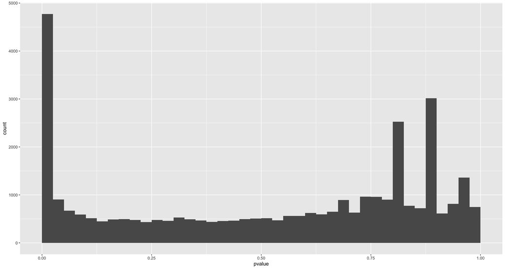

```r
ggplot(awde, aes(x = pvalue)) +
  geom_histogram(binwidth = 0.025, boundary = 0)
```

Here, we estimate the proportion of true null hypothesis which is indicated by the blue line. In the first bin of the histogram you can see that there are much more p-values than in the rest of the histogram. This is exactly what we expected. Now we try to find out which part of the p-values that are smaller than alpha belong to the true null hypotheses and which ones belong to the correctly rejected null hypotheses.

In the first bin [0, $\alpha$] there are 4772 p-values. Of these, 945 are below the blue line, which means that they are most likely true nulls.

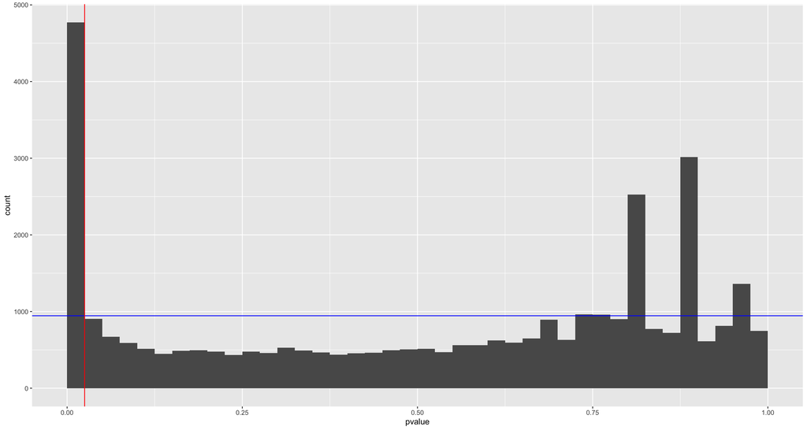

```r
alpha = binw = 0.025
pi0 = 2 * mean(awde$pvalue > 0.5)
ggplot(awde,
  aes(x = pvalue)) + geom_histogram(binwidth = binw, boundary = 0) +
  geom_hline(yintercept = pi0 * binw * nrow(awde), col = "blue") +
  geom_vline(xintercept = alpha, col = "red")
```

Now we can calculate the proportion of false discoveries.

```r
pi0 * alpha / mean(awde$pvalue <= alpha)
```

```
## [1] 0.1980092
```

### The Benjamini-Hochberg algorithm for controlling the FDR

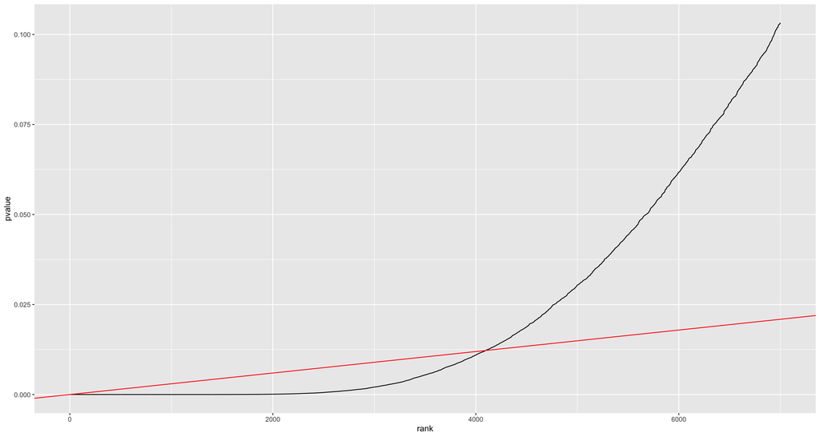

```r
phi  = 0.10 # Target FDR
awde = mutate(awde, rank = rank(pvalue))
m    = nrow(awde)

ggplot(dplyr::filter(awde, rank <= 7000), aes(x = rank, y = pvalue)) +
  geom_line() + geom_abline(slope = phi / m, col = "red")
```

```r
kmax = with(arrange(awde, rank),
         last(which(pvalue <= phi * rank / m)))
kmax
```

```
## [1] 4099
```

```r
phi* kmax / m
```

```
## [1] 0.01224715
```

```r
arrange(awde, rank)[kmax,]
```

```
##      baseMean log2FoldChange     lfcSE     stat     pvalue       padj rank
## 4099 343.2954      0.3330165 0.1329097 2.505586 0.01222488 0.05395106 4099
```

```r
arrange(awde, rank)[kmax + 1,]
```

```
##      baseMean log2FoldChange     lfcSE     stat     pvalue       padj rank
## 4100 69.72638       0.654578 0.2613513 2.504591 0.01225931 0.05408979 4100
```

**Exercise:**

Look at the `p.adjust` function and try to reproduce the results from the above analysis!

```r
awde = mutate(awde, p_adjust_function = p.adjust(pvalue, method = "BH"))
```

## The local FDR

```r
library("fdrtool")
ft = fdrtool(awde$pvalue, statistic = "pvalue")
```

```
## Step 1... determine cutoff point
## Step 2... estimate parameters of null distribution and eta0
## Step 3... compute p-values and estimate empirical PDF/CDF
## Step 4... compute q-values and local fdr
## Step 5... prepare for plotting
```

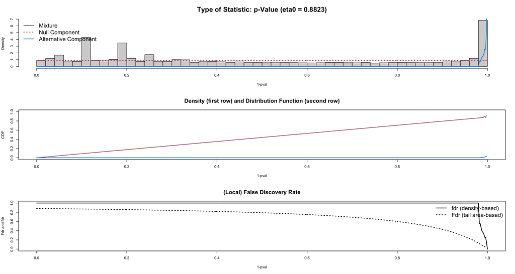

```r
ft$param[,"eta0"]
```

```
##      eta0
## 0.8822922
```

# Further reading

Halsey, Lewis G, Douglas Curran-Everett, Sarah L Vowler, and Gordon B Drummond. 2015. “The Fickle P Value Generates Irreproducible Results.” *Nature Methods* 12 (3): 179–85.

Holmes, Susan, and Wolfgang Huber. 2018. *Modern Statistics for Modern Biology*. Cambridge University Press.